# 5th assignment

Bastien Cadiou

24/03/2022

# The data

```r
n=200
mu <- c(1,2)
Sigma <- matrix(c(1, 0.5, 0.5, 2),2,2)
set.seed(1234)
sample <- rmvnorm(n, mu, Sigma)

sample=as.data.frame(sample)
sapply(sample, mean, na.rm = TRUE)                  ### not parallel
```

```
##       V1       V2
## 1.012694 2.007053
```

```r
cov(sample)
```

```
##           V1        V2
## V1 1.0396159 0.6051607
## V2 0.6051607 2.1386796
```

# The tests

Now we will run two test about the hypothesis :
$$\mathcal{H}_0 : \mathcal{A}\mu = a$$
vs
$$\mathcal{H}_1 : \mathcal{A}\mu \ne a$$
where $\mathcal{A} =\begin{pmatrix}2\\-1\end{pmatrix}$ and $a = 0$.

#### With $\Sigma$ known

We know that, under $\mathcal{H}_0$, the likelihood ratio statistic follows a chi2 statistic, with one degree of freedom.

We calculate it, such as the quantile of the chi2 distribution, with a level of 95 %.

```r
a <- 0
A <- c(2, -1)
Tvalue <- n * t(A %*% apply(sample, 2, mean) - a) %*% solve(A %*% Sigma %*% A) %*% (A %*% apply(sample, 2, mean) - a)
Tvalue
```

```
##            [,1]
## [1,] 0.01680831
```

```r
qchisq(0.95,df=1)
```

```
## [1] 3.841459
```

Because the T value is way under the quantile, we can not reject $\mathcal{H}_0$, therefore we accept it.

#### With $\Sigma$ unknown

Although the process is quite similar, we now perform a test where the statistic follows a Fisher distribution with 1 and (n-1) degrees of freedom.

```r
TTvalue <- (n - 1) * t(A %*% apply(sample, 2, mean) - a) %*% solve(A %*% cov(sample) %*% A) %*% (A %*% apply(sample, 2, mean) - a)
TTvalue
```

```
##            [,1]
## [1,] 0.01725708
```

```r
qf(0.95,df1 = 1,df2=(n-1))
```

```
## [1] 3.888613
```

Once again, we can not reject $\mathcal{H}_0$, because the T value is way under the quantile of the Fisher distribution.

### Type errors

We can find the type erros of these tests :

```r
#install.packages('pwr')
library(pwr)
#?pwr.chisq.test
pwr.chisq.test(w=Tvalue,N=n,df=1,sig.level = 0.95)
```

```
##
##      Chi squared power calculation
##
##               w = 0.01680831
##               N = 200
##              df = 1
##       sig.level = 0.95
##           power = 0.951391
##
## NOTE: N is the number of observations
```

```r
#?pwr.f2.test
pwr.f2.test(u=1,v=(n-1),f2=TTvalue,sig.level=0.95)
```

```
##
##      Multiple regression power calculation
##
##               u = 1
##               v = 199
##              f2 = 0.01725708
##       sig.level = 0.95
##           power = 0.9911539
```

We know having a high power number is a good criteria to decide if the test is appropriate or not. Thus, both tests look interesting.

We can calculate the Type Error II, which is :
$$Type Error II = 1 - power$$
.

## Data from the alternative hypothesis

Now, we will look into the same tests, but with data that does nos follow the null hypothesis such that :
$$\mathcal{H}_1 : \mathcal{A}\mu \ne a$$

We will run the same two tests with the hypothesis of $\Sigma$ know first and then unknown.

```r
#new data
n=200
mu <- c(1,2)
Sigma <- matrix(c(1, 0.5, 0.5, 2),2,2)
set.seed(1234)
sample <- rmvnorm(n, mu, Sigma)
sample=as.data.frame(sample)
#sapply(sample, mean, na.rm = TRUE)

#Sigma known
a <- 2
A <- c(2,-1)
Tvalue <- n * t(A %*% apply(sample, 2, mean) - a) %*% solve(A %*% Sigma %*% A) %*% (A %*% apply(sample, 2, mean) - a)
Tvalue
```

```
##          [,1]
## [1,] 196.3498
```

```r
qchisq(0.95,df=1)
```

```
## [1] 3.841459
```

```r
#Sigma unknown
TTvalue <- (n - 1) * t(A %*% apply(sample, 2, mean) - a) %*% solve(A %*% cov(sample) %*% A) %*% (A %*% apply(sample, 2, mean) - a)
TTvalue
```

```
##          [,1]
## [1,] 201.5922
```

```r
qf(0.95,df1 = 1,df2=(n-1))
```

```
## [1] 3.888613
```

Here, we reject the null hypothesis in both cases because the statistic is way bigger than the distribution quantile.

# Global Perfomance

Let’s iterate the test using n to see how the test behave while changing the n.

```r
mu <- c(1,2)
Sigma <- matrix(c(1, 0.5, 0.5, 2),2,2)
a <- 0
A <- c(2, -1)

first_test = NULL
second_test = NULL
type_error_2_1 = NULL
type_error_2_2 = NULL

for (i in 10:5000){
                 n = i
                 sample = rmvnorm(n, mean = mu, sigma = Sigma)

                 #First test
                 Tvalue = n* t(A %*% apply(sample, 2, mean) - a) %*% solve(A %*% Sigma %*% A) %*% (A %*% apply(sample, 2, mean) - a)
                 first_test = c(first_test, Tvalue > qchisq(0.95, df = 1))
                 type_error_2_1 = c(type_error_2_1,1 - pwr.chisq.test(w=Tvalue,N=n,df=1,sig.level = 0.95)$power)

                 #Second test
                 TTvalue <- (n - 1) * t(A %*% apply(sample, 2, mean) - a) %*% solve(A %*% cov(sample) %*% A) %*% (A %*% apply(sample, 2, mean) - a)
                 second_test = c(second_test, TTvalue > qf(0.95, df1 = 1, df2 = n-1))
                 type_error_2_2 = c(type_error_2_2, 1 - pwr.f2.test(u = 1,v = (n-1), f2 = TTvalue, sig.level = 0.05)$power)
}

mean(type_error_2_1)
```

```
## [1] 0.00662695
```

```r
mean(type_error_2_2)
```

```
## [1] 0.04201238
```

```r
sum(first_test)/4990
```

```
## [1] 0.05490982
```

```r
sum(second_test)/4990
```

```
## [1] 0.05410822
```

# Graphical outputs

if we plot the Type Error II for both tests, we obtain these graphics.

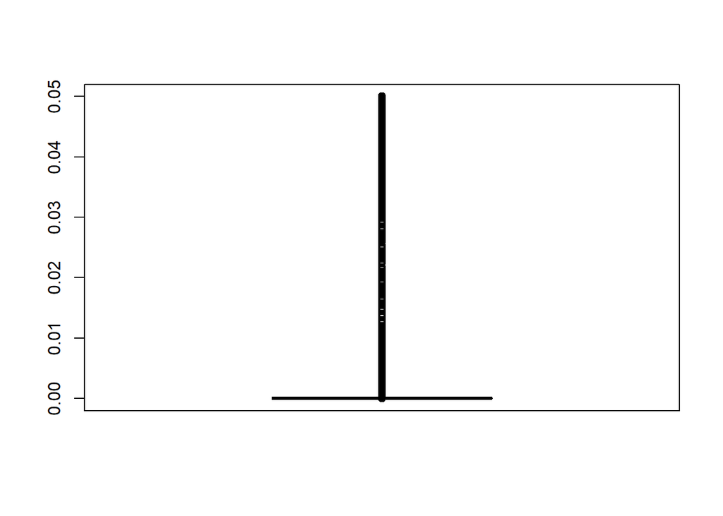

```r
boxplot(type_error_2_1)
```

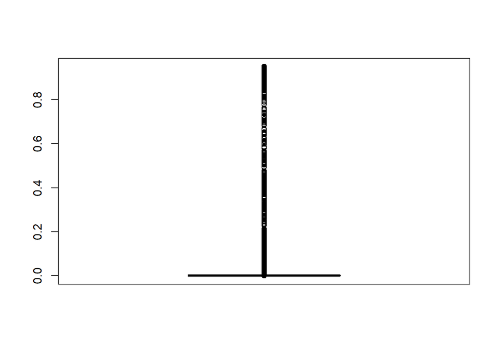

```r
boxplot(type_error_2_2)
```

We can see most of the values are close to zero, which is a good thing. However, while the first boxplot has only values between $0$ and $0.05$, the second has values rising to more than $0.8$.

This implies that if the $\Sigma$ is known, the tests are more precise.